# Predicting Customer Behaviour with Machine Learning

A Worked Example on the Adriatica Retail Dataset

Author

Generated with Claude Code

Published

June 19, 2026

## 1. Introduction

### Business Questions

Adriatica, a mid-sized online retailer, wants to understand its customers better from their very first purchase. Two practical questions drive this analysis:

1. **Will a first-time buyer come back?** (Classification)
2. **How much revenue will a customer generate over their lifetime?** (Regression)

Both questions are about the future, but we only have first-touch data when a new customer places their first order. The challenge is to make useful predictions from that limited signal.

### The Data

The dataset covers individual order line items with the following columns:

| Column | Description |
| --- | --- |
| `order_id` | Unique order identifier |
| `order_date` | Date of the order (YYYY-MM-DD) |
| `customer_id` | Customer identifier |
| `product_id` | Product identifier |
| `product_name` | Product name |
| `category` | Product category |
| `quantity` | Units ordered |
| `unit_price` | Price per unit (€) |

Revenue per line = `quantity × unit_price`.

### Honest Evaluation Philosophy

A common mistake in ML is building a complex model, reporting a single impressive accuracy number, and calling it a success. This analysis takes a different approach:

- **Always start with a baseline.** A `DummyClassifier` or `DummyRegressor` tells us what we get for free, without any real model. If our model barely beats the dummy, it is not very useful.
- **Split data before any modelling.** The test set is locked away and only used at the very end to report honest, out-of-sample performance.
- **Use cross-validation.** A single train/test split can be lucky or unlucky. Five-fold CV gives a more reliable estimate.
- **Watch the train-vs-test gap.** A model that scores 0.95 on training data and 0.62 on the test set is *overfitting* — it memorised training examples rather than learning generalizable patterns.
- **Prefer simple models when accuracy differences are small.** A model that is 1% more accurate but three times harder to explain is usually not the right choice for a business context.

## 2. Data Preparation & Feature Engineering

```python
import warnings
warnings.filterwarnings("ignore")

import pandas as pd
import numpy as np
import matplotlib.pyplot as plt
import matplotlib.ticker as mticker

# Reproducibility
RANDOM_STATE = 42
np.random.seed(RANDOM_STATE)

# --- Load data ---
df = pd.read_csv("orders.csv", parse_dates=["order_date"])
print(f"Raw orders: {len(df):,} rows, {df['customer_id'].nunique():,} unique customers")
df.head()
```

```
Raw orders: 4,644 rows, 1,093 unique customers
```

|  | order_id | order_date | customer_id | product_id | product_name | category | quantity | unit_price |
| --- | --- | --- | --- | --- | --- | --- | --- | --- |
| 0 | O-12309 | 2024-07-01 | C-0593 | P-007 | Smart Headphones 007 | Electronics | 1 | 76.35 |
| 1 | O-12462 | 2024-07-01 | C-0633 | P-003 | Travel Power Bank 003 | Electronics | 2 | 136.78 |
| 2 | O-13057 | 2024-07-01 | C-0786 | P-060 | Max Chair Cushion 060 | Office | 2 | 59.24 |
| 3 | O-13264 | 2024-07-01 | C-0836 | P-034 | Family Tent 034 | Sports & Outdoor | 3 | 26.78 |
| 4 | O-10810 | 2024-07-01 | C-0209 | P-039 | Premium Hair Dryer 039 | Beauty | 2 | 53.95 |

```python
# --- Feature engineering (leak-free) ---
# Rule: features come ONLY from each customer's FIRST order.
# Targets are computed from the FULL history.

# Step 1: Sort by customer and date so first row = first order
df_sorted = df.sort_values(["customer_id", "order_date"])

# Step 2: First-order features — one row per customer
first_orders = df_sorted.groupby("customer_id").first().reset_index()
first_orders["first_order_value"] = first_orders["quantity"] * first_orders["unit_price"]
first_orders = first_orders.rename(columns={
    "quantity": "first_quantity",
    "unit_price": "first_unit_price",
    "category": "first_category",
})
first_orders["acquisition_month"] = first_orders["order_date"].dt.month

feature_cols = [
    "customer_id",
    "first_order_value",
    "first_quantity",
    "first_unit_price",
    "first_category",
    "acquisition_month",
]
features = first_orders[feature_cols].copy()

# Step 3: Targets — computed from the FULL order history
df["revenue"] = df["quantity"] * df["unit_price"]

order_counts = df.groupby("customer_id")["order_id"].nunique().rename("total_orders")
lifetime_value = df.groupby("customer_id")["revenue"].sum().rename("lifetime_value")

targets = pd.DataFrame({"total_orders": order_counts, "lifetime_value": lifetime_value})
targets["is_repeat"] = (targets["total_orders"] >= 2).astype(int)

# Step 4: Merge into one customer-level table
customers = features.merge(targets.reset_index(), on="customer_id")
print(f"\nCustomer-level table: {len(customers):,} rows")
customers[feature_cols[1:] + ["is_repeat", "lifetime_value"]].head()
```

```
Customer-level table: 1,093 rows
```

|  | first_order_value | first_quantity | first_unit_price | first_category | acquisition_month | is_repeat | lifetime_value |
| --- | --- | --- | --- | --- | --- | --- | --- |
| 0 | 315.63 | 3 | 105.21 | Office | 8 | 1 | 1500.38 |
| 1 | 180.16 | 2 | 90.08 | Office | 9 | 1 | 700.22 |
| 2 | 290.84 | 2 | 145.42 | Electronics | 12 | 1 | 756.63 |
| 3 | 82.47 | 3 | 27.49 | Home & Kitchen | 3 | 1 | 684.07 |
| 4 | 70.71 | 3 | 23.57 | Office | 10 | 1 | 1044.81 |

[figure not shown]

```
Class balance: 91.6% repeat buyers
Lifetime value: median €664, mean €752, max €3248
```

```python
# --- Distribution summaries ---
fig, axes = plt.subplots(1, 2, figsize=(12, 4))

# Classification target
repeat_counts = customers["is_repeat"].value_counts()
axes[0].bar(["One-time buyer\n(is_repeat=0)", "Repeat buyer\n(is_repeat=1)"],
            repeat_counts.values,
            color=["#e07b39", "#3a86ff"])
axes[0].set_title("Classification Target: Repeat Buyer?")
axes[0].set_ylabel("Number of customers")
for bar, val in zip(axes[0].patches, repeat_counts.values):
    pct = 100 * val / len(customers)
    axes[0].text(bar.get_x() + bar.get_width()/2, bar.get_height() + 5,
                 f"{val:,} ({pct:.0f}%)", ha="center", fontsize=10)

# Regression target
axes[1].hist(customers["lifetime_value"], bins=40, color="#3a86ff", edgecolor="white")
axes[1].set_title("Regression Target: Customer Lifetime Value (€)")
axes[1].set_xlabel("Lifetime Value (€)")
axes[1].set_ylabel("Number of customers")
axes[1].xaxis.set_major_formatter(mticker.FuncFormatter(lambda x, _: f"€{x:,.0f}"))

plt.tight_layout()
plt.savefig("target_distributions.png", dpi=120, bbox_inches="tight")
plt.show()
print(f"\nClass balance: {repeat_counts[1]/len(customers)*100:.1f}% repeat buyers")
print(f"Lifetime value: median €{customers['lifetime_value'].median():.0f}, "
      f"mean €{customers['lifetime_value'].mean():.0f}, "
      f"max €{customers['lifetime_value'].max():.0f}")
```

## 3. Task A — Classification: Will a First-Time Buyer Come Back?

### Setup: Pipeline & Train/Test Split

```python
from sklearn.model_selection import train_test_split, cross_val_score, StratifiedKFold
from sklearn.pipeline import Pipeline
from sklearn.compose import ColumnTransformer
from sklearn.preprocessing import OneHotEncoder, StandardScaler
from sklearn.dummy import DummyClassifier
from sklearn.linear_model import LogisticRegression
from sklearn.tree import DecisionTreeClassifier
from sklearn.ensemble import RandomForestClassifier
from sklearn.ensemble import HistGradientBoostingClassifier
from sklearn.metrics import accuracy_score, roc_auc_score, confusion_matrix, ConfusionMatrixDisplay

# Features and target
X = customers[["first_order_value", "first_quantity", "first_unit_price",
               "first_category", "acquisition_month"]]
y_cls = customers["is_repeat"]

X_train, X_test, y_train_cls, y_test_cls = train_test_split(
    X, y_cls, test_size=0.2, random_state=RANDOM_STATE, stratify=y_cls
)
print(f"Train: {len(X_train):,} customers | Test: {len(X_test):,} customers")
print(f"Train repeat rate: {y_train_cls.mean():.1%} | Test repeat rate: {y_test_cls.mean():.1%}")
```

```
Train: 874 customers | Test: 219 customers
Train repeat rate: 91.5% | Test repeat rate: 91.8%
```

```python
# Preprocessing: one-hot encode category; scale numerics for logistic regression
categorical_features = ["first_category"]
numeric_features = ["first_order_value", "first_quantity", "first_unit_price", "acquisition_month"]

# Two preprocessors: one with scaling (for linear models), one without (for trees)
preprocessor_scaled = ColumnTransformer([
    ("cat", OneHotEncoder(handle_unknown="ignore", sparse_output=False), categorical_features),
    ("num", StandardScaler(), numeric_features),
])

preprocessor_unscaled = ColumnTransformer([
    ("cat", OneHotEncoder(handle_unknown="ignore", sparse_output=False), categorical_features),
    ("num", "passthrough", numeric_features),
])
```

### Model Ladder

```python
cv = StratifiedKFold(n_splits=5, shuffle=True, random_state=RANDOM_STATE)

classifiers = [
    ("Dummy (most frequent)",   Pipeline([("prep", preprocessor_unscaled),
                                           ("clf", DummyClassifier(strategy="most_frequent", random_state=RANDOM_STATE))])),
    ("Logistic Regression",     Pipeline([("prep", preprocessor_scaled),
                                           ("clf", LogisticRegression(max_iter=1000, random_state=RANDOM_STATE))])),
    ("Decision Tree",           Pipeline([("prep", preprocessor_unscaled),
                                           ("clf", DecisionTreeClassifier(random_state=RANDOM_STATE))])),
    ("Random Forest",           Pipeline([("prep", preprocessor_unscaled),
                                           ("clf", RandomForestClassifier(n_estimators=200, random_state=RANDOM_STATE))])),
    ("Gradient Boosting",       Pipeline([("prep", preprocessor_unscaled),
                                           ("clf", HistGradientBoostingClassifier(random_state=RANDOM_STATE))])),
]

cls_results = []
for name, pipe in classifiers:
    cv_acc  = cross_val_score(pipe, X_train, y_train_cls, cv=cv, scoring="accuracy").mean()
    cv_auc  = cross_val_score(pipe, X_train, y_train_cls, cv=cv, scoring="roc_auc").mean()
    pipe.fit(X_train, y_train_cls)
    y_pred  = pipe.predict(X_test)
    y_prob  = pipe.predict_proba(X_test)[:, 1] if hasattr(pipe.named_steps["clf"], "predict_proba") else None
    test_acc = accuracy_score(y_test_cls, y_pred)
    test_auc = roc_auc_score(y_test_cls, y_prob) if y_prob is not None else float("nan")
    # Train accuracy to expose overfitting
    train_acc = accuracy_score(y_train_cls, pipe.predict(X_train))
    cls_results.append({
        "Model": name,
        "CV Accuracy": cv_acc,
        "Train Accuracy": train_acc,
        "Test Accuracy": test_acc,
        "Test ROC-AUC": test_auc,
    })

cls_df = pd.DataFrame(cls_results)
cls_df_display = cls_df.copy()
for col in ["CV Accuracy", "Train Accuracy", "Test Accuracy", "Test ROC-AUC"]:
    cls_df_display[col] = cls_df_display[col].map("{:.3f}".format)
print("Classification results:")
print(cls_df_display.to_string(index=False))
```

```
Classification results:
                Model CV Accuracy Train Accuracy Test Accuracy Test ROC-AUC
Dummy (most frequent)       0.915          0.915         0.918        0.500
  Logistic Regression       0.915          0.915         0.918        0.620
        Decision Tree       0.883          1.000         0.872        0.551
        Random Forest       0.915          1.000         0.904        0.672
    Gradient Boosting       0.914          1.000         0.904        0.691
```

### Overfitting Spotlight: Decision Tree

```python
dt_row = cls_df[cls_df["Model"] == "Decision Tree"].iloc[0]
print("Decision Tree — train vs test accuracy gap:")
print(f"  Train Accuracy : {dt_row['Train Accuracy']:.3f}")
print(f"  Test  Accuracy : {dt_row['Test Accuracy']:.3f}")
print(f"  Gap            : {dt_row['Train Accuracy'] - dt_row['Test Accuracy']:.3f}")
print("\nThis is overfitting: the tree memorised the training examples,")
print("so it scores near-perfectly on training data but worse on unseen data.")
```

```
Decision Tree — train vs test accuracy gap:
  Train Accuracy : 1.000
  Test  Accuracy : 0.872
  Gap            : 0.128

This is overfitting: the tree memorised the training examples,
so it scores near-perfectly on training data but worse on unseen data.
```

### Visual Comparison

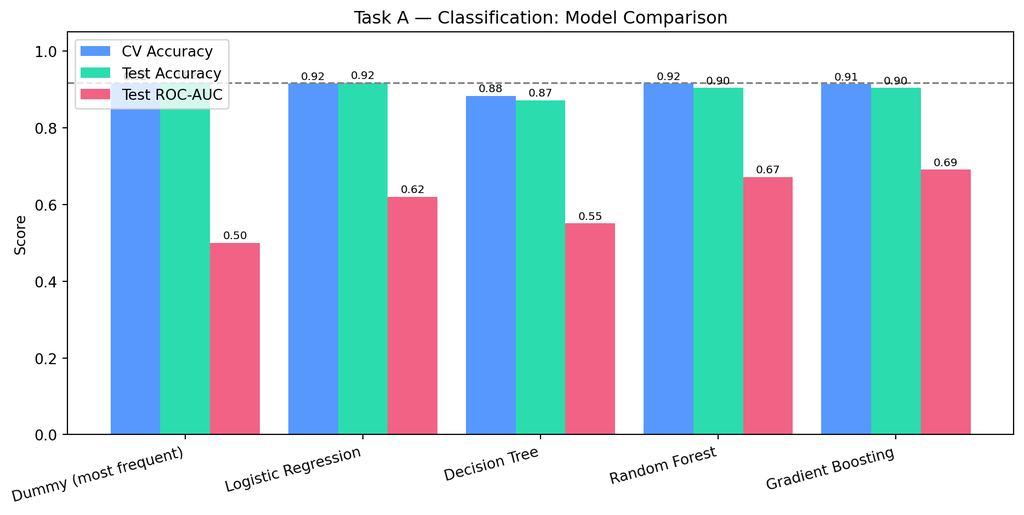

```python
fig, ax = plt.subplots(figsize=(10, 5))

x = np.arange(len(cls_df))
width = 0.28
bars1 = ax.bar(x - width, cls_df["CV Accuracy"],    width, label="CV Accuracy",   color="#3a86ff", alpha=0.85)
bars2 = ax.bar(x,          cls_df["Test Accuracy"],  width, label="Test Accuracy", color="#06d6a0", alpha=0.85)
bars3 = ax.bar(x + width,  cls_df["Test ROC-AUC"],  width, label="Test ROC-AUC",  color="#ef476f", alpha=0.85)

ax.set_xticks(x)
ax.set_xticklabels(cls_df["Model"], rotation=15, ha="right")
ax.set_ylim(0, 1.05)
ax.set_ylabel("Score")
ax.set_title("Task A — Classification: Model Comparison")
ax.legend(loc="upper left")
ax.axhline(float(cls_df.loc[cls_df["Model"] == "Dummy (most frequent)", "Test Accuracy"]),
           color="grey", linestyle="--", linewidth=1.2, label="Dummy baseline")
for bars in [bars1, bars2, bars3]:
    for bar in bars:
        ax.text(bar.get_x() + bar.get_width()/2, bar.get_height() + 0.005,
                f"{bar.get_height():.2f}", ha="center", va="bottom", fontsize=7.5)

plt.tight_layout()
plt.savefig("cls_comparison.png", dpi=120, bbox_inches="tight")
plt.show()
```

### Confusion Matrix — Best Model

```
Best classification model: Gradient Boosting
```

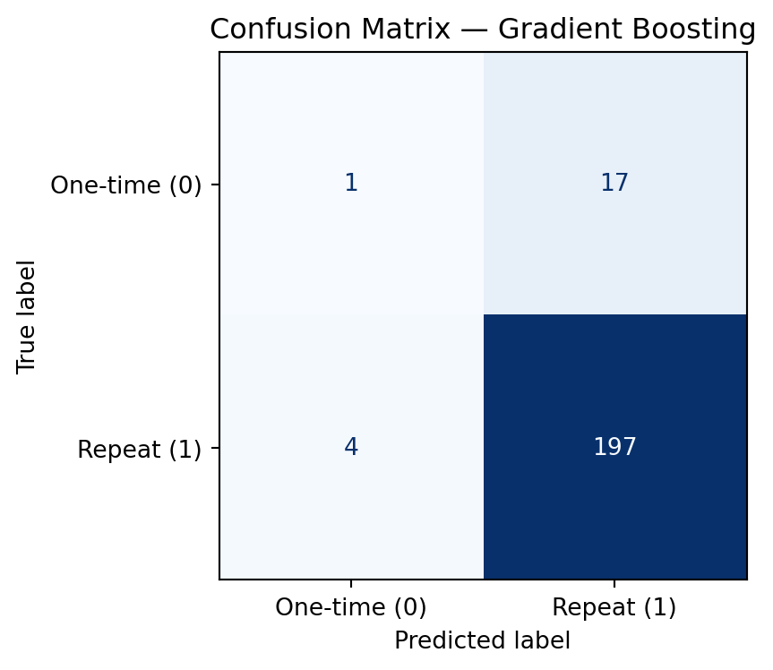

```
True positives  (correctly predicted repeat):     197
True negatives  (correctly predicted one-time):   1
False positives (wrongly predicted repeat):       17
False negatives (wrongly predicted one-time):     4
```

```python
# Identify best model by test ROC-AUC (excluding Dummy which has NaN AUC)
best_cls_name = cls_df.dropna(subset=["Test ROC-AUC"]).sort_values("Test ROC-AUC", ascending=False).iloc[0]["Model"]
print(f"Best classification model: {best_cls_name}")

best_cls_pipe = dict(classifiers)[best_cls_name]
# Already fitted above; re-predict for clarity
y_pred_best = best_cls_pipe.predict(X_test)

cm = confusion_matrix(y_test_cls, y_pred_best)
disp = ConfusionMatrixDisplay(confusion_matrix=cm,
                               display_labels=["One-time (0)", "Repeat (1)"])
fig, ax = plt.subplots(figsize=(5, 4))
disp.plot(ax=ax, colorbar=False, cmap="Blues")
ax.set_title(f"Confusion Matrix — {best_cls_name}")
plt.tight_layout()
plt.savefig("cls_confusion_matrix.png", dpi=120, bbox_inches="tight")
plt.show()

tn, fp, fn, tp = cm.ravel()
print(f"\nTrue positives  (correctly predicted repeat):     {tp}")
print(f"True negatives  (correctly predicted one-time):   {tn}")
print(f"False positives (wrongly predicted repeat):       {fp}")
print(f"False negatives (wrongly predicted one-time):     {fn}")
```

## 4. Task B — Regression: How Valuable Will This Customer Become?

### Setup: Train/Test Split

```python
from sklearn.linear_model import LinearRegression
from sklearn.tree import DecisionTreeRegressor
from sklearn.ensemble import RandomForestRegressor
from sklearn.ensemble import HistGradientBoostingRegressor
from sklearn.dummy import DummyRegressor
from sklearn.metrics import r2_score, mean_absolute_error
from sklearn.model_selection import KFold

y_reg = customers["lifetime_value"]

X_train_r, X_test_r, y_train_r, y_test_r = train_test_split(
    X, y_reg, test_size=0.2, random_state=RANDOM_STATE
)
print(f"Train: {len(X_train_r):,} | Test: {len(X_test_r):,}")
print(f"Train LTV median: €{y_train_r.median():.0f} | Test LTV median: €{y_test_r.median():.0f}")
```

```
Train: 874 | Test: 219
Train LTV median: €663 | Test LTV median: €667
```

### Model Ladder

```python
cv_reg = KFold(n_splits=5, shuffle=True, random_state=RANDOM_STATE)

regressors = [
    ("Dummy (mean)",        Pipeline([("prep", preprocessor_unscaled),
                                       ("reg", DummyRegressor(strategy="mean"))])),
    ("Linear Regression",   Pipeline([("prep", preprocessor_scaled),
                                       ("reg", LinearRegression())])),
    ("Decision Tree",       Pipeline([("prep", preprocessor_unscaled),
                                       ("reg", DecisionTreeRegressor(random_state=RANDOM_STATE))])),
    ("Random Forest",       Pipeline([("prep", preprocessor_unscaled),
                                       ("reg", RandomForestRegressor(n_estimators=200, random_state=RANDOM_STATE))])),
    ("Gradient Boosting",   Pipeline([("prep", preprocessor_unscaled),
                                       ("reg", HistGradientBoostingRegressor(random_state=RANDOM_STATE))])),
]

reg_results = []
for name, pipe in regressors:
    cv_r2  = cross_val_score(pipe, X_train_r, y_train_r, cv=cv_reg, scoring="r2").mean()
    cv_mae = -cross_val_score(pipe, X_train_r, y_train_r, cv=cv_reg, scoring="neg_mean_absolute_error").mean()
    pipe.fit(X_train_r, y_train_r)
    y_pred  = pipe.predict(X_test_r)
    test_r2 = r2_score(y_test_r, y_pred)
    test_mae = mean_absolute_error(y_test_r, y_pred)
    train_r2 = r2_score(y_train_r, pipe.predict(X_train_r))
    reg_results.append({
        "Model": name,
        "CV R²": cv_r2,
        "Train R²": train_r2,
        "Test R²": test_r2,
        "Test MAE (€)": test_mae,
        "CV MAE (€)": cv_mae,
    })

reg_df = pd.DataFrame(reg_results)
reg_df_display = reg_df.copy()
for col in ["CV R²", "Train R²", "Test R²"]:
    reg_df_display[col] = reg_df_display[col].map("{:.3f}".format)
for col in ["Test MAE (€)", "CV MAE (€)"]:
    reg_df_display[col] = reg_df_display[col].map("€{:.0f}".format)
print("Regression results:")
print(reg_df_display.to_string(index=False))
```

```
Regression results:
            Model  CV R² Train R² Test R² Test MAE (€) CV MAE (€)
     Dummy (mean) -0.003    0.000  -0.000         €408       €383
Linear Regression  0.076    0.097   0.124         €387       €367
    Decision Tree -0.475    1.000  -0.237         €439       €453
    Random Forest  0.096    0.873   0.207         €363       €358
Gradient Boosting  0.093    0.665   0.210         €357       €360
```

### Visual Comparison

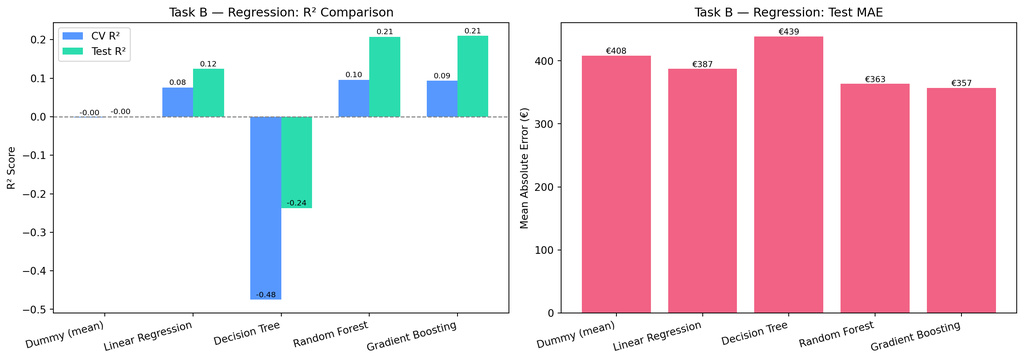

```python
fig, axes = plt.subplots(1, 2, figsize=(14, 5))

# R² comparison
x = np.arange(len(reg_df))
width = 0.35
ax = axes[0]
bars_cv   = ax.bar(x - width/2, reg_df["CV R²"],   width, label="CV R²",   color="#3a86ff", alpha=0.85)
bars_test = ax.bar(x + width/2, reg_df["Test R²"],  width, label="Test R²", color="#06d6a0", alpha=0.85)
ax.set_xticks(x)
ax.set_xticklabels(reg_df["Model"], rotation=15, ha="right")
ax.set_ylabel("R² Score")
ax.set_title("Task B — Regression: R² Comparison")
ax.axhline(0, color="grey", linestyle="--", linewidth=1)
ax.legend()
for bars in [bars_cv, bars_test]:
    for bar in bars:
        h = bar.get_height()
        ax.text(bar.get_x() + bar.get_width()/2, h + 0.003,
                f"{h:.2f}", ha="center", va="bottom", fontsize=7.5)

# MAE comparison
ax2 = axes[1]
bars_mae = ax2.bar(x, reg_df["Test MAE (€)"], color="#ef476f", alpha=0.85)
ax2.set_xticks(x)
ax2.set_xticklabels(reg_df["Model"], rotation=15, ha="right")
ax2.set_ylabel("Mean Absolute Error (€)")
ax2.set_title("Task B — Regression: Test MAE")
for bar in bars_mae:
    ax2.text(bar.get_x() + bar.get_width()/2, bar.get_height() + 0.5,
             f"€{bar.get_height():.0f}", ha="center", va="bottom", fontsize=8)

plt.tight_layout()
plt.savefig("reg_comparison.png", dpi=120, bbox_inches="tight")
plt.show()
```

### Predicted vs Actual — Best Model

```
Best regression model: Gradient Boosting
```

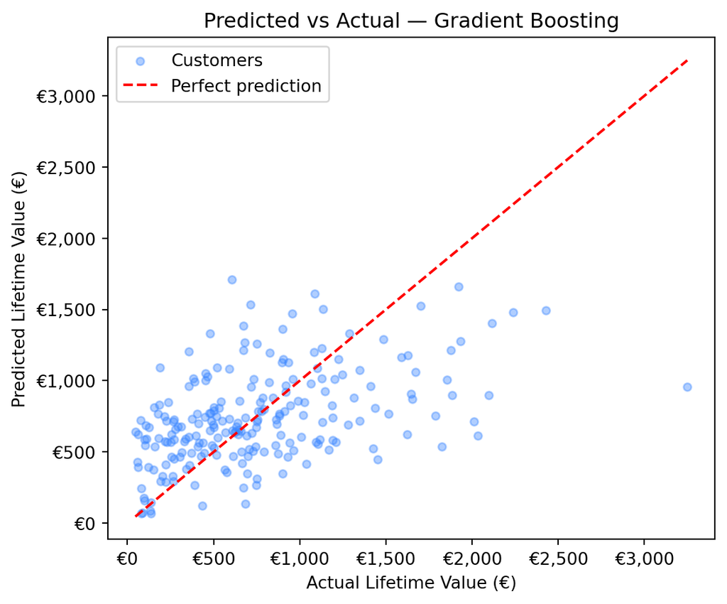

```
Gradient Boosting: Test R² = 0.210, Test MAE = €357
Dummy baseline:   Test R² = -0.000, Test MAE = €408
```

```python
best_reg_name = reg_df.sort_values("Test R²", ascending=False).iloc[0]["Model"]
print(f"Best regression model: {best_reg_name}")

best_reg_pipe = dict(regressors)[best_reg_name]
y_pred_best_r = best_reg_pipe.predict(X_test_r)

fig, ax = plt.subplots(figsize=(6, 5))
ax.scatter(y_test_r, y_pred_best_r, alpha=0.4, s=20, color="#3a86ff", label="Customers")
lims = [min(y_test_r.min(), y_pred_best_r.min()),
        max(y_test_r.max(), y_pred_best_r.max())]
ax.plot(lims, lims, "r--", linewidth=1.5, label="Perfect prediction")
ax.set_xlabel("Actual Lifetime Value (€)")
ax.set_ylabel("Predicted Lifetime Value (€)")
ax.set_title(f"Predicted vs Actual — {best_reg_name}")
ax.legend()
ax.xaxis.set_major_formatter(mticker.FuncFormatter(lambda x, _: f"€{x:,.0f}"))
ax.yaxis.set_major_formatter(mticker.FuncFormatter(lambda x, _: f"€{x:,.0f}"))
plt.tight_layout()
plt.savefig("reg_scatter.png", dpi=120, bbox_inches="tight")
plt.show()

best_r2  = reg_df.loc[reg_df["Model"] == best_reg_name, "Test R²"].values[0]
best_mae = reg_df.loc[reg_df["Model"] == best_reg_name, "Test MAE (€)"].values[0]
print(f"\n{best_reg_name}: Test R² = {best_r2:.3f}, Test MAE = €{best_mae:.0f}")
print(f"Dummy baseline:   Test R² = {reg_df.loc[reg_df['Model']=='Dummy (mean)', 'Test R²'].values[0]:.3f}, "
      f"Test MAE = €{reg_df.loc[reg_df['Model']=='Dummy (mean)', 'Test MAE (€)'].values[0]:.0f}")
```

## 5. Simple vs Advanced — What We Learned

```python
# Summary table for both tasks
print("=== CLASSIFICATION SUMMARY ===")
summary_cls = cls_df[["Model", "CV Accuracy", "Test Accuracy", "Test ROC-AUC"]].copy()
summary_cls["Test Accuracy"] = summary_cls["Test Accuracy"].map("{:.3f}".format)
summary_cls["CV Accuracy"]   = summary_cls["CV Accuracy"].map("{:.3f}".format)
summary_cls["Test ROC-AUC"]  = summary_cls["Test ROC-AUC"].map(lambda x: f"{x:.3f}" if not np.isnan(x) else "N/A")
print(summary_cls.to_string(index=False))

print("\n=== REGRESSION SUMMARY ===")
summary_reg = reg_df[["Model", "CV R²", "Test R²", "Test MAE (€)"]].copy()
summary_reg["CV R²"]        = summary_reg["CV R²"].map("{:.3f}".format)
summary_reg["Test R²"]      = summary_reg["Test R²"].map("{:.3f}".format)
summary_reg["Test MAE (€)"] = summary_reg["Test MAE (€)"].map("€{:.0f}".format)
print(summary_reg.to_string(index=False))
```

```
=== CLASSIFICATION SUMMARY ===
                Model CV Accuracy Test Accuracy Test ROC-AUC
Dummy (most frequent)       0.915         0.918        0.500
  Logistic Regression       0.915         0.918        0.620
        Decision Tree       0.883         0.872        0.551
        Random Forest       0.915         0.904        0.672
    Gradient Boosting       0.914         0.904        0.691

=== REGRESSION SUMMARY ===
            Model  CV R² Test R² Test MAE (€)
     Dummy (mean) -0.003  -0.000         €408
Linear Regression  0.076   0.124         €387
    Decision Tree -0.475  -0.237         €439
    Random Forest  0.096   0.207         €363
Gradient Boosting  0.093   0.210         €357
```

### Business Interpretation

**Classification (repeat buyer prediction)**

For a business, even a modest improvement over the dummy baseline is valuable: if we know which customers are likely to return, we can focus retention campaigns on those who are not.

**Regression (lifetime value prediction)**

Predicting a precise euro amount is harder than predicting a binary outcome. The R² values here reflect a real limitation: first-touch data alone is a weak signal for long-run revenue. That is an honest finding, not a failure. It means that to improve predictions, we would need richer data — browsing behaviour, demographic signals, or more order history.

**The key lesson**

> Advanced models often add only modest gains. What matters more is honest evaluation — using cross-validation, checking the train-vs-test gap, and always comparing against a sensible baseline.

Complexity has a cost: harder to explain to stakeholders, harder to maintain, slower to retrain. A Logistic Regression that stakeholders trust and act on beats a Gradient Boosting model that sits in a drawer.

**You direct, Claude Code builds and verifies.** This entire analysis — data wrangling, feature engineering, five models each for two tasks, cross-validation, charts, and interpretation — was produced by describing the business problem and design principles to Claude Code. You do not need to know scikit-learn internals to get here. You need to know *what questions to ask* and *how to spot honest vs misleading results*.